# Project_VisitWithUs_Tourism

### Build Bagging Model

```python
bagging_estimator=BaggingClassifier(random_state=1)
bagging_estimator.fit(X_train,y_train)
```

```
BaggingClassifier(random_state=1)
```

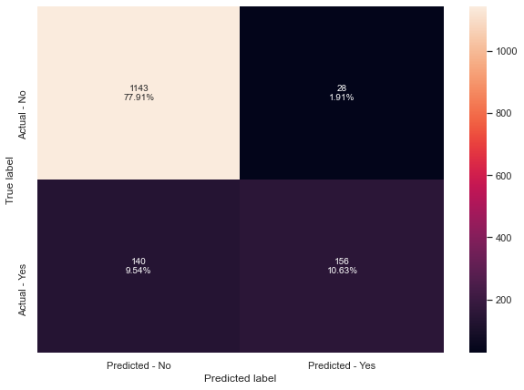

```python
make_confusion_matrix(bagging_estimator,y_test)
```

```python
#Return the scoring metrics
bagging_estimator_score=get_metrics_score(bagging_estimator)
```

```
Accuracy on training set :  0.9912306343174511
Accuracy on test set :  0.885480572597137
Recall on training set :  0.9519230769230769
Recall on test set :  0.527027027027027
Precision on training set :  1.0
Precision on test set :  0.8478260869565217
```

**Insights**

- The bagging model without any hyperparameters is overfitting the model as you can see the accuaracy is higher for training set compared to the test set
- The model can be improved

### Build Bagging Model with Grid Search

```python
bagging_estimator_tuned = BaggingClassifier(random_state=1)

parameters = {

            'max_samples': [0.7,0.8,0.9,1],
              'max_features': [0.7,0.8,0.9,1],
              'n_estimators' : [10,20,30,40,50,100,150],
             }

# use recall as metric to maximize
acc_scorer = metrics.make_scorer(metrics.recall_score)

t1 = datetime.now()
grid_obj = GridSearchCV(bagging_estimator_tuned, parameters, scoring=acc_scorer,cv=5,verbose=10,n_jobs=-1)
grid_obj = grid_obj.fit(X_train, y_train)
t2 =datetime.now()
print("Grid Search takes %0.2f mins"%((t2-t1).seconds/60))

bagging_estimator_tuned = grid_obj.best_estimator_

# Fit the best algorithm to the data.
bagging_estimator_tuned.fit(X_train, y_train)
```

```
Fitting 5 folds for each of 112 candidates, totalling 560 fits
```

[output not shown]

```
Grid Search takes 1.12 mins
```

```
BaggingClassifier(max_features=0.9, max_samples=0.9, n_estimators=100,
                  random_state=1)
```

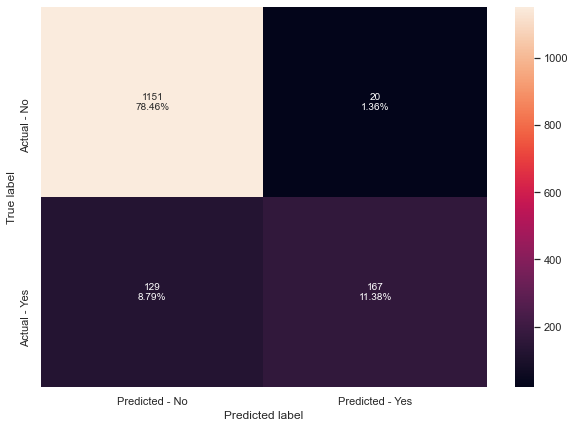

```python
make_confusion_matrix(bagging_estimator_tuned,y_test)
```

```python
bagging_estimator_tuned_score=get_metrics_score(bagging_estimator_tuned)
```

```
Accuracy on training set :  0.9997076878105817
Accuracy on test set :  0.8984321745057942
Recall on training set :  0.9983974358974359
Recall on test set :  0.5641891891891891
Precision on training set :  1.0
Precision on test set :  0.893048128342246
```

**Insights**

- The tuned bagging model worked performed better on recall than standard bagging model, but the model is overfitted since Accuracy on training set is much higher than test set

### Build Random Forest Model

```python
#Train the random forest classifier
rf_estimator=RandomForestClassifier(random_state=1)
rf_estimator.fit(X_train,y_train)
```

```
RandomForestClassifier(random_state=1)
```

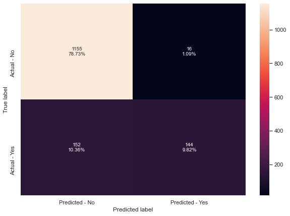

```python
make_confusion_matrix(rf_estimator,y_test)
```

```python
rf_estimator_tuned_score=get_metrics_score(rf_estimator)
```

```
Accuracy on training set :  1.0
Accuracy on test set :  0.885480572597137
Recall on training set :  1.0
Recall on test set :  0.4864864864864865
Precision on training set :  1.0
Precision on test set :  0.9
```

**Insights**

- The the untuned random forest model is overfitted and can be improved. Will use grid search to look for best model

### Build Random Forest Model using grid search

```python
rf_estimator_tuned = RandomForestClassifier(random_state=1)


parameters = {
    "class_weight": [{0: 0.2, 1: 0.8}],
    "n_estimators": [150,200,250],
    "min_samples_leaf": np.arange(5, 10),
    "max_features": np.arange(0.2, 0.7, 0.1),
    "max_samples": np.arange(0.3, 0.7, 0.1),
             }

acc_scorer = metrics.make_scorer(metrics.recall_score)

# Run the grid search

t1 = datetime.now()
grid_obj = GridSearchCV(rf_estimator_tuned, parameters, scoring=acc_scorer,cv=5,verbose=10,n_jobs=-1)
grid_obj = grid_obj.fit(X_train, y_train)
t2 =datetime.now()
print("Grid Search takes %0.2f mins"%((t2-t1).seconds/60))

rf_estimator_tuned = grid_obj.best_estimator_

rf_estimator_tuned.fit(X_train, y_train)
```

```
Fitting 5 folds for each of 300 candidates, totalling 1500 fits
```

[output not shown]

```
Grid Search takes 6.35 mins
```

```
RandomForestClassifier(class_weight={0: 0.2, 1: 0.8},
                       max_features=0.6000000000000001,
                       max_samples=0.6000000000000001, min_samples_leaf=9,
                       n_estimators=250, random_state=1)
```

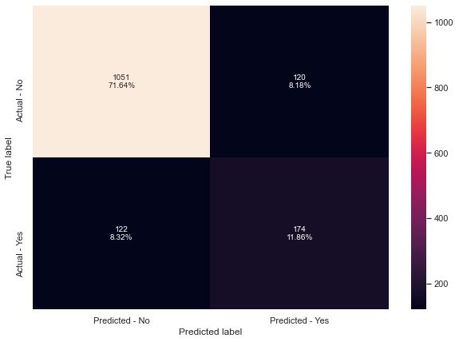

```python
make_confusion_matrix(rf_estimator_tuned,y_test)
```

```python
# get metrics
rf_estimator_tuned_score=get_metrics_score(rf_estimator_tuned)
```

```
Accuracy on training set :  0.8789827535808243
Accuracy on test set :  0.8350374914792092
Recall on training set :  0.7596153846153846
Recall on test set :  0.5878378378378378
Precision on training set :  0.6422764227642277
Precision on test set :  0.5918367346938775
```

**Insights**

- The tuned random forest model is slightly overfited, but performs much better on recall metric than the non-tuned model

### Build AdaBoost Model

```python
abc = AdaBoostClassifier(random_state=1)
abc.fit(X_train,y_train)
```

```
AdaBoostClassifier(random_state=1)
```

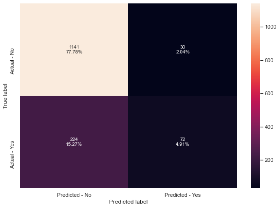

```python
make_confusion_matrix(abc,y_test)
```

```python
#Using above defined function to get accuracy, recall and precision on train and test set
abc_score=get_metrics_score(abc)
```

```
Accuracy on training set :  0.8497515346389944
Accuracy on test set :  0.8268575323790047
Recall on training set :  0.2948717948717949
Recall on test set :  0.24324324324324326
Precision on training set :  0.7131782945736435
Precision on test set :  0.7058823529411765
```

**Insights**

- The model is not overfitted, but it performes terrible on accuracy and recall. It can be improved

### Build AdaBoost Model with grid search

```python
abc_tuned = AdaBoostClassifier(random_state=1)


parameters = {
    #Let's try different max_depth for base_estimator
    "base_estimator":[DecisionTreeClassifier(max_depth=1),DecisionTreeClassifier(max_depth=2),DecisionTreeClassifier(max_depth=3)],
    "n_estimators": np.arange(10,110,10),
    "learning_rate":np.arange(0.1,0.8,0.1)
}


acc_scorer = metrics.make_scorer(metrics.recall_score)

# Run the grid search
t1 = datetime.now()
grid_obj = GridSearchCV(abc_tuned, parameters, scoring=acc_scorer,cv=5,verbose=10,n_jobs=-1)
grid_obj = grid_obj.fit(X_train, y_train)
t2 =datetime.now()
print("Grid Search takes %0.2f mins"%((t2-t1).seconds/60))


abc_tuned = grid_obj.best_estimator_


abc_tuned.fit(X_train, y_train)
```

```
Fitting 5 folds for each of 210 candidates, totalling 1050 fits
```

[output not shown]

```
Grid Search takes 1.97 mins
```

```
AdaBoostClassifier(base_estimator=DecisionTreeClassifier(max_depth=3),
                   learning_rate=0.5, n_estimators=100, random_state=1)
```

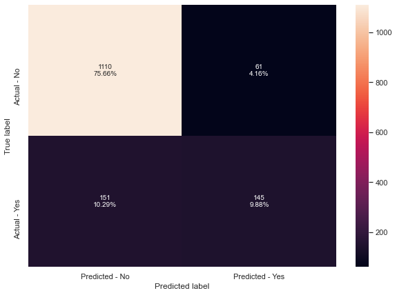

```python
make_confusion_matrix(abc_tuned,y_test)
```

```python
#Using above defined function to get accuracy, recall and precision on train and test set
abc_tuned_score=get_metrics_score(abc_tuned)
```

```
Accuracy on training set :  0.9505992399883075
Accuracy on test set :  0.8554873892297206
Recall on training set :  0.7788461538461539
Recall on test set :  0.48986486486486486
Precision on training set :  0.9400386847195358
Precision on test set :  0.7038834951456311
```

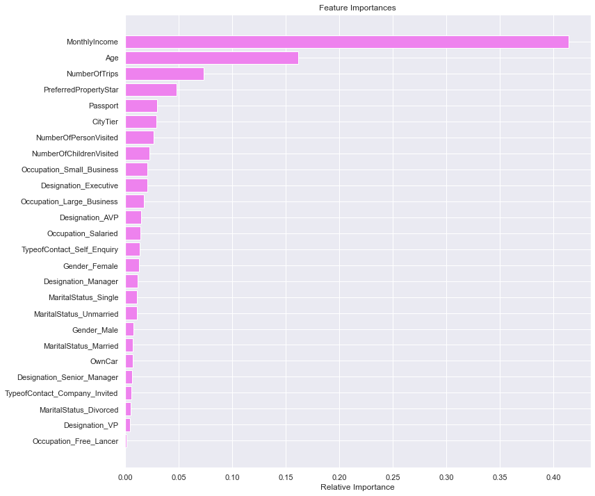

```python
importances = abc_tuned.feature_importances_
indices = np.argsort(importances)
feature_names = list(X.columns)

plt.figure(figsize=(12,12))
plt.title('Feature Importances')
plt.barh(range(len(indices)), importances[indices], color='violet', align='center')
plt.yticks(range(len(indices)), [feature_names[i] for i in indices])
plt.xlabel('Relative Importance')
plt.show()
```

**Insights**

- The tuned abc model is overfited, but the recall improved compared to the non-tuned abc model. Monthly income and age are the most important variables

### Build GradientBoosting Model

```python
gbc = GradientBoostingClassifier(random_state=1)
gbc.fit(X_train,y_train)
```

```
GradientBoostingClassifier(random_state=1)
```

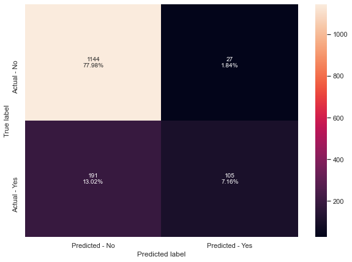

```python
make_confusion_matrix(gbc,y_test)
```

```python
gbc_score=get_metrics_score(gbc)
```

```
Accuracy on training set :  0.8824904998538439
Accuracy on test set :  0.8513974096796183
Recall on training set :  0.42948717948717946
Recall on test set :  0.3547297297297297
Precision on training set :  0.8535031847133758
Precision on test set :  0.7954545454545454
```

**Insights**

- The model is not overfitted, but did not perform well on recall or accuracy. It can be improved

### Build GradientBoosting Model with Grid search

```python
# Choose the type of classifier.
gbc_tuned = GradientBoostingClassifier(init=AdaBoostClassifier(random_state=1),random_state=1)


parameters = {
    "n_estimators": [100,150,200,250],
    "subsample":[0.8,0.9,1],
    "max_features":[0.7,0.8,0.9,1]
}


acc_scorer = metrics.make_scorer(metrics.recall_score)

# Run the grid search
t1 = datetime.now()
grid_obj = GridSearchCV(gbc_tuned, parameters, scoring=acc_scorer,cv=5,verbose=10,n_jobs=-1)
grid_obj = grid_obj.fit(X_train, y_train)
t2 =datetime.now()
print("Grid Search takes %0.2f mins"%((t2-t1).seconds/60))


gbc_tuned = grid_obj.best_estimator_

# Fit the best algorithm to the data.
gbc_tuned.fit(X_train, y_train)
```

```
Fitting 5 folds for each of 48 candidates, totalling 240 fits
```

[output not shown]

```
Grid Search takes 1.27 mins
```

```
GradientBoostingClassifier(init=AdaBoostClassifier(random_state=1),
                           max_features=0.9, n_estimators=250, random_state=1,
                           subsample=1)
```

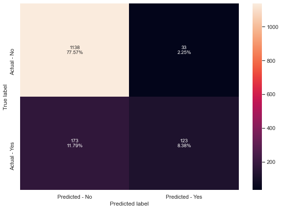

```python
make_confusion_matrix(gbc_tuned,y_test)
```

```python
#Using above defined function to get accuracy, recall and precision on train and test set
gbc_tuned_score=get_metrics_score(gbc_tuned)
```

```
Accuracy on training set :  0.912014030985092
Accuracy on test set :  0.8595773687798227
Recall on training set :  0.5689102564102564
Recall on test set :  0.4155405405405405
Precision on training set :  0.917312661498708
Precision on test set :  0.7884615384615384
```

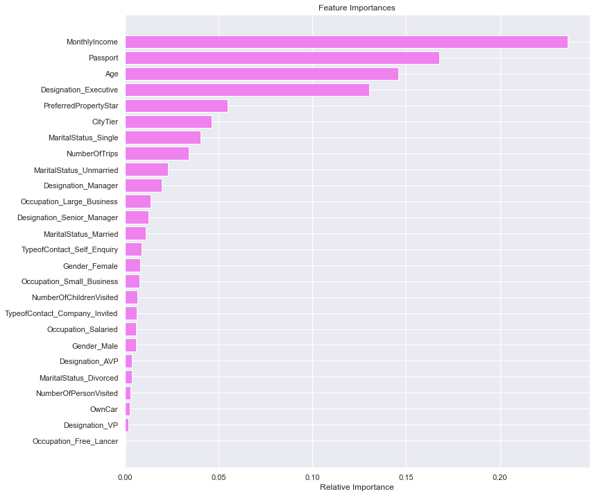

```python
importances = gbc_tuned.feature_importances_
indices = np.argsort(importances)
feature_names = list(X.columns)

plt.figure(figsize=(12,12))
plt.title('Feature Importances')
plt.barh(range(len(indices)), importances[indices], color='violet', align='center')
plt.yticks(range(len(indices)), [feature_names[i] for i in indices])
plt.xlabel('Relative Importance')
plt.show()
```

**Insights**

- The gradient boosting with Grid search is slightly overfitted. The most important variables are MonthlyIncome and Passport and Age

### Build XGBoost model

```python
xgb = XGBClassifier(random_state=1)
xgb.fit(X_train,y_train)
```

```
[08:50:26] WARNING: C:/Users/Administrator/workspace/xgboost-win64_release_1.3.0/src/learner.cc:1061: Starting in XGBoost 1.3.0, the default evaluation metric used with the objective 'binary:logistic' was changed from 'error' to 'logloss'. Explicitly set eval_metric if you'd like to restore the old …
```

```
XGBClassifier(base_score=0.5, booster='gbtree', colsample_bylevel=1,
              colsample_bynode=1, colsample_bytree=1, gamma=0, gpu_id=-1,
              importance_type='gain', interaction_constraints='',
              learning_rate=0.300000012, max_delta_step=0, max_depth=6,
              min_child_weight=1, missing=nan, monotone_constraints='()',
              n_estimators=100, n_jobs=8, num_parallel_tree=1, random_state=1,
              reg_alpha=0, reg_lambda=1, scale_pos_weight=1, subsample=1,
              tree_method='exact', validate_parameters=1, verbosity=None)
```

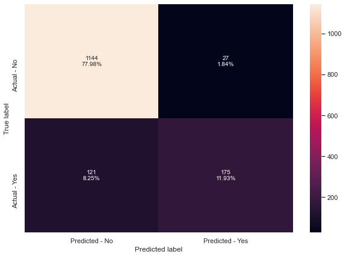

```python
make_confusion_matrix(xgb,y_test)
```

```python
xgb_score=get_metrics_score(xgb)
```

```
Accuracy on training set :  0.9976615024846536
Accuracy on test set :  0.8991138377641446
Recall on training set :  0.9871794871794872
Recall on test set :  0.5912162162162162
Precision on training set :  1.0
Precision on test set :  0.8663366336633663
```

**Insights**

- The model is overfitted to the training data when you review the accuaracy on training set and Test set.Training set is almost 100% accuarate vs 90% for test set. The model can be improved.

### Build XGBoosting Model with grid search

```python
# Choose the type of classifier.
xgb_tuned = XGBClassifier(random_state=1)

# Grid of parameters to choose from
## add from
parameters = {
    "n_estimators": np.arange(10,100,20),
    "scale_pos_weight":[0,1,2,5],
    "subsample":[0.5,0.7,0.9,1],
    "learning_rate":[0.01,0.1,0.2,0.05],
    "gamma":[0,1,3],
    "colsample_bytree":[0.5,0.7,0.9,1],
    "colsample_bylevel":[0.5,0.7,0.9,1]
}

# Type of scoring used to compare parameter combinations
acc_scorer = metrics.make_scorer(metrics.recall_score)

# Run the grid search
t1 = datetime.now()
grid_obj = GridSearchCV(xgb_tuned, parameters, scoring=acc_scorer,cv=5,verbose=10,n_jobs=-1)
grid_obj = grid_obj.fit(X_train, y_train)
t2 =datetime.now()
print("Grid Search takes %0.2f mins"%((t2-t1).seconds/60))

# Set the clf to the best combination of parameters
xgb_tuned = grid_obj.best_estimator_

# Fit the best algorithm to the data.
xgb_tuned.fit(X_train, y_train)
```

```
Fitting 5 folds for each of 15360 candidates, totalling 76800 fits
```

[output not shown]

[output cut: 337 more lines]

[output not shown]

```
[10:45:13] WARNING: C:/Users/Administrator/workspace/xgboost-win64_release_1.3.0/src/learner.cc:1061: Starting in XGBoost 1.3.0, the default evaluation metric used with the objective 'binary:logistic' was changed from 'error' to 'logloss'. Explicitly set eval_metric if you'd like to restore the old …
Grid Search takes 94.50 mins
[10:45:13] WARNING: C:/Users/Administrator/workspace/xgboost-win64_release_1.3.0/src/learner.cc:1061: Starting in XGBoost 1.3.0, the default evaluation metric used with the objective 'binary:logistic' was changed from 'error' to 'logloss'. Explicitly set eval_metric if you'd like to restore the old …
```

```
XGBClassifier(base_score=0.5, booster='gbtree', colsample_bylevel=0.5,
              colsample_bynode=1, colsample_bytree=0.7, gamma=1, gpu_id=-1,
              importance_type='gain', interaction_constraints='',
              learning_rate=0.2, max_delta_step=0, max_depth=6,
              min_child_weight=1, missing=nan, monotone_constraints='()',
              n_estimators=10, n_jobs=8, num_parallel_tree=1, random_state=1,
              reg_alpha=0, reg_lambda=1, scale_pos_weight=5, subsample=0.9,
              tree_method='exact', validate_parameters=1, verbosity=None)
```

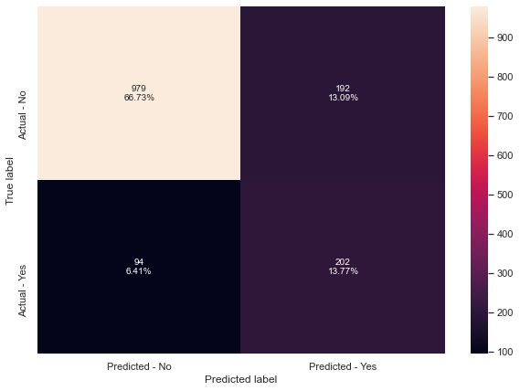

```python
make_confusion_matrix(xgb_tuned,y_test)
```

```python
#Using above defined function to get accuracy, recall and precision on train and test set
xgb_tuned_score=get_metrics_score(xgb_tuned)
```

```
Accuracy on training set :  0.8567670271850336
Accuracy on test set :  0.8050443081117927
Recall on training set :  0.8685897435897436
Recall on test set :  0.6824324324324325
Precision on training set :  0.5705263157894737
Precision on test set :  0.5126903553299492
```

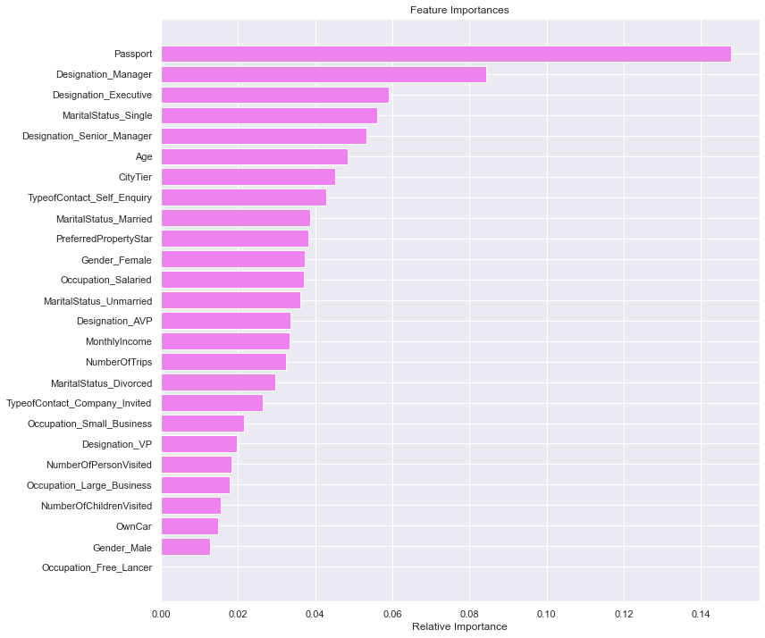

```python
importances = xgb_tuned.feature_importances_
indices = np.argsort(importances)
feature_names = list(X.columns)

plt.figure(figsize=(12,12))
plt.title('Feature Importances')
plt.barh(range(len(indices)), importances[indices], color='violet', align='center')
plt.yticks(range(len(indices)), [feature_names[i] for i in indices])
plt.xlabel('Relative Importance')
plt.show()
```

**Insights**

- The XGboost with Grid search performed well. There is a slight overfit, but recall is 68% on the test set. The most important variables are Passport and Designation of manager

### Build Stacked Model with tuned decison Tree, Tuned Random Forest and tuned Gradient Boosting

```python
estimators=[('Decision Tree', dtree_tuned),('Random Forest', rf_estimator_tuned),
           ('Gradient Boosting', gbc_tuned)]
final_estimator=XGBClassifier(random_state=1)
```

```python
stacking_estimator=StackingClassifier(estimators=estimators, final_estimator=final_estimator,cv=5)
stacking_estimator.fit(X_train,y_train)
```

```
[10:35:25] WARNING: C:/Users/Administrator/workspace/xgboost-win64_release_1.3.0/src/learner.cc:1061: Starting in XGBoost 1.3.0, the default evaluation metric used with the objective 'binary:logistic' was changed from 'error' to 'logloss'. Explicitly set eval_metric if you'd like to restore the old …
```

```
StackingClassifier(cv=5,
                   estimators=[('Decision Tree',
                                DecisionTreeClassifier(class_weight={0: 0.2,
                                                                     1: 0.8},
                                                       max_depth=5,
                                                       max_leaf_nodes=10,
                                                       min_impurity_decrease=0.001,
                                                       random_state=1)),
                               ('Random Forest',
                                RandomForestClassifier(class_weight={0: 0.2,
                                                                     1: 0.8},
                                                       max_features=0.6000000000000001,
                                                       max_samples=0.6000000000000001,
                                                       min_samples_leaf=9,
                                                       n_estimators=250,
                                                       random_s...
                                                 importance_type='gain',
                                                 interaction_constraints=None,
                                                 learning_rate=None,
                                                 max_delta_step=None,
                                                 max_depth=None,
                                                 min_child_weight=None,
                                                 missing=nan,
                                                 monotone_constraints=None,
                                                 n_estimators=100, n_jobs=None,
                                                 num_parallel_tree=None,
                                                 random_state=1, reg_alpha=None,
                                                 reg_lambda=None,
                                                 scale_pos_weight=None,
                                                 subsample=None,
                                                 tree_method=None,
                                                 validate_parameters=None,
                                                 verbosity=None))
```

```python
#Using above defined function to get accuracy, recall and precision on train and test set
stacking_estimator_score=get_metrics_score(stacking_estimator)
```

```
Accuracy on training set :  0.8921368021046477
Accuracy on test set :  0.8384458077709611
Recall on training set :  0.5384615384615384
Recall on test set :  0.40540540540540543
Precision on training set :  0.8057553956834532
Precision on test set :  0.6629834254143646
```

**Insights**

- The stacked model was slightly overfitted. The model didn't perform well. It could be improved if we improved the underlying models.

## Comparing all models

```python
# defining list of models
models = [dTree, dtree_tuned, rf_estimator, rf_estimator_tuned, abc, abc_tuned, gbc, gbc_tuned, xgb,
         xgb_tuned, stacking_estimator]

# defining empty lists to add train and test results
train_acc = []
test_acc = []
train_recall= []
test_recall= []
train_precision= []
test_precision= []


#train_acc,test_acc,train_recall,test_recall,train_precision,test_precision
# looping through all the models to get the rmse and r2 scores
for model in models:
    # accuracy score
    j = get_metrics_score(model,False)
    train_acc.append(j[0])
    test_acc.append(j[1])
    train_recall.append(j[2])
    test_recall.append(j[3])
    train_precision.append(j[4])
    test_precision.append(j[5])
```

```python
comparison_frame = pd.DataFrame({'Model':['Decision Tree','Tuned Decision Tree','Random Forest','Tuned Random Forest',
                                          'AdaBoost Classifier', 'Tuned AdaBoost Classifier',
                                          'Gradient Boosting Classifier', 'Tuned Gradient Boosting Classifier',
                                          'XGBoost Classifier',  'Tuned XGBoost Classifier','Stacking Classifier'],
                                          'Training Accuracy': train_acc,'Test Accuracy': test_acc,
                                          'Training Recall':train_recall,'Test Recall':test_recall,
                                          'Training Precision':train_precision,'Test Precision':test_precision})
comparison_frame
```

[output not shown]